# SCQA

Situation: 有發展潛力的蝦皮賣場會被加入白名單指派管理人以提供更多協助，在資料庫中2022年底的白名單賣場有將近24,000家

Complication: 但是2023年初的卻只剩下12,000家

Question: 這個數量的減少是因為資料有缺漏，還是真的就是減少了那麼多?

Answer: 真的就是減少那麼多!

# Load & Transform

df1: 2022年底抓取到的白名單賣場資料

df2: 2023年初抓取到的白名單賣場資料

```python
import numpy as np
import pandas as pd
pd.options.display.max_rows = None
pd.set_option('display.float_format', '{:,.2f}'.format)
import matplotlib.pyplot as plt
# plt.style.use('seaborn-whitegrid')
import seaborn as sns
sns.set()
import warnings
warnings.filterwarnings("ignore")
```

```python
import os
os.chdir('/Users/alexlo/Desktop/Project/Intern_Shopee/SPX_Whitelist/rawdata')
df1 = pd.read_excel('白名單賣家Quarterly Update.xlsx', sheet_name='2022Q4')
df2 = pd.read_csv('sptwspxs_705_whitelist_update_20230206-155505.csv')
```

```python
df1 = df1.drop(columns=['Unnamed: 15'])
df1.sp_exist = df1.sp_exist.fillna(0)
df2.sp_exist = df2.sp_exist.fillna(0)

df1 = df1.astype({
            'shop_category': 'category',
            'account_owner': 'category',
            'whitelist_type': 'category',
            'seller_city': 'category',
            'seller_dist': 'category',
            'sp_exist':'boolean',
          })
df2 = df2.astype({
            'shop_category': 'category',
            'account_owner': 'category',
            'whitelist_type': 'category',
            'seller_city': 'category',
            'seller_dist': 'category',
            'sp_exist':'boolean',
          });
```

```python
print('df1:', df1.shape)
print('df2:', df2.shape)
```

```
df1: (24470, 15)
df2: (12175, 15)
```

原先有超過 24,000 家白名單賣場，但是短短一季卻只剩下 12,000 多家。

# Old Dataset vs New Dataset

i.e. df1 vs df2

```python
print('df1: \n', df1.is_official_shop.value_counts(), '\n')
print('df2: \n', df2.is_official_shop.value_counts(), '\n')
```

```
df1:
 is_official_shop
0    18868
1     5602
Name: count, dtype: int64

df2:
 is_official_shop
0    6577
1    5598
Name: count, dtype: int64
```

絕大多數都少在非官方的賣場

```python
pd.DataFrame([
    df1.seller_city.value_counts(),
    df2.seller_city.value_counts(),
]).transpose()
```

| seller_city | count | count |
| --- | --- | --- |
| 新北市 | 5944 | 3191 |
| 臺北市 | 3996 | 2094 |
| 臺中市 | 3981 | 1869 |
| 桃園市 | 3108 | 1523 |
| 高雄市 | 2280 | 1073 |
| 臺南市 | 1524 | 702 |
| 彰化縣 | 899 | 451 |
| 新竹縣 | 396 | 206 |
| 新竹市 | 346 | 146 |
| 嘉義市 | 292 | 141 |
| 雲林縣 | 247 | 112 |
| 苗栗縣 | 244 | 104 |
| 宜蘭縣 | 235 | 95 |
| 屏東縣 | 224 | 90 |
| 嘉義縣 | 218 | 112 |
| 基隆市 | 198 | 83 |
| 南投縣 | 145 | 74 |
| 花蓮縣 | 27 | 12 |
| 臺東縣 | 8 | 4 |
| 澎湖縣 | 2 | 2 |
| 金門縣 | 2 | 2 |

沒有單獨一個地區有特別顯著的差異

```python
pd.DataFrame([
    df1.whitelist_type.value_counts(),
    df2.whitelist_type.value_counts(),
]).transpose()
```

| whitelist_type | count | count |
| --- | --- | --- |
| P4 | 16999 | 6954 |
| P1 | 3578 | 2935 |
| P2 | 3086 | 1809 |
| P3(10+) | 486 | 219 |
| P3(50+) | 194 | 172 |
| P3(30+) | 127 | 86 |

在各種等級的賣家中，等級最低的P4減少最多，將近10,000家

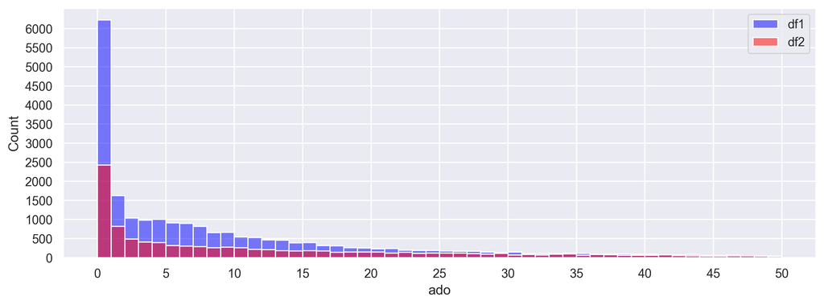

```python
plt.figure(figsize=(12,4), dpi=300)
plt.setp(
    sns.histplot(
        data=df1.query('0 <= ado and ado <= 50'),
        x='ado', binwidth=1, color='blue', alpha=0.5,
    ),
    yticks=np.arange(0,6500,500), xticks=np.arange(0,20,2),
)
plt.setp(
    sns.histplot(
        data=df2.query('0 <= ado and ado <= 50'),
        x='ado', binwidth=1, color='red', alpha=0.5,
    ),
    yticks=np.arange(0,6500,500), xticks=np.arange(0,51,5),
)
plt.legend(['df1', 'df2']);
```

Ado(average daily order) 愈少的賣場消失的愈多，絕大多數集中在 0~1 之間

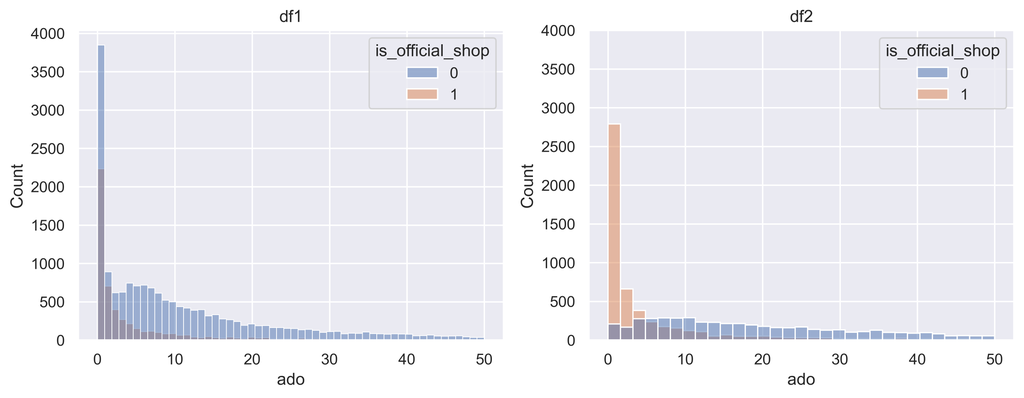

```python
fig, (ax1, ax2) = plt.subplots(1, 2, figsize=(12, 4), dpi=500)
sns.histplot(
        data=df1.query('ado <= 50'),
        x='ado', hue='is_official_shop', ax=ax1
)
sns.histplot(
        data=df2.query('ado <= 50'),
        x='ado', hue='is_official_shop', ax=ax2
)
plt.setp(ax1, yticks=np.arange(0, 4500, 500), title='df1')
plt.setp(ax2, yticks=np.arange(0, 4500, 500), title='df2')
plt.show()
```

1. 不可能單純將低Ado的賣場從白名單中移除，因為官方的低Ado賣場幾乎都不受影響
2. Ado 影響一定很大，因為大多數消失的賣場就是來自低 Ado 賣場

```python
account_owner1 = df1.account_owner.value_counts().reset_index().rename(columns={'count':'old_counts'})
account_owner2 = df2.account_owner.value_counts().reset_index().rename(columns={'count':'new_counts'})
df_account_owner = pd.merge(account_owner1, account_owner2, on='account_owner').reset_index(drop=True)
df_account_owner['diff'] = df_account_owner['new_counts'] - df_account_owner['old_counts']
df_account_owner['admin'] = 'Admin' + df_account_owner.index.astype(str) #遮蔽管理人信箱
```

```python
print(
    '管理賣場數減少最多的十個管理人: \n',
    df_account_owner[['admin', 'old_counts', 'new_counts', 'diff']]
        .query('diff < 0').sort_values('diff').head(10).reset_index(drop=True), '\n'
)
print(
    '管理賣場數增加最多的十個管理人: \n',
    df_account_owner[['admin', 'old_counts', 'new_counts', 'diff']]
        .query('diff > 0').sort_values('diff', ascending=False).head(10).reset_index(drop=True), '\n'
)
```

```
管理賣家數減少最多的十個管理人:
       admin  old_counts  new_counts  diff
0    Admin0        2582         386 -2196
1    Admin1        2566         387 -2179
2    Admin2        2557         384 -2173
3    Admin3        2517         379 -2138
4    Admin4        2493         384 -2109
5   Admin93          50           1   -49
6   Admin65          67          29   -38
7   Admin10         145         110   -35
8  Admin102          45          10   -35
9   Admin11         138         107   -31

管理賣家數增加最多的十個管理人:
       admin  old_counts  new_counts  diff
0    Admin8         192         391   199
1    Admin6         195         388   193
2    Admin5         196         385   189
3    Admin7         194         377   183
4  Admin142           5          81    76
5   Admin22          89         138    49
6   Admin42          73         119    46
7   Admin91          56         101    45
8  Admin121          20          58    38
9   Admin36          77         107    30
```

絕大多數消失的白名單賣場都集中在5個管理人手上，同時仍然有管理人獲得更多白名單賣場可知資料並非單純消失

# Conclusion

## Data insight

觀察到:

1. 消失的賣場幾乎全部都是非官方賣場
2. 消失的賣場都是Ado較低的賣場，愈低的消失愈多，尤其是0~1之間
3. 消失的賣場集中在5位管理人身上

可能推測:

1. 白名單的門檻有改變，導致許多低Ado的賣場被移除，不過Ado絕不是唯一的標準
2. 5位管理人的資料有出錯(可能是舊資料、也可能是新資料)，除非是有其他因素大量改變了他們管理的賣場

## Follow-up & Result

請同仁向白名單專案負責人確認，得知**2023年初開始制度有變**:

1. 原本有少數幾人要獨自負責2,000多家，後來要求每人都控制在400家上下
2. Ado 是其中一個決定是否能成為白名單賣場的門檻，此門檻確實有改變

結論，**現在的資料庫是正確的!**